# Risk-Based Mapping of Arsenic Contamination in Bangladesh: A Geostatistical Approach using Indicator Simulation and Kriging

- Show All Code
- Hide All Code

Author

Florian Josephowitz, Tobias Hölzer, Ben Lefebvre

Published

March 16, 2025

```python
# ruff: noqa: N803, N806
from typing import Callable

import branca
import geopandas as gpd
import odc.geo.xr  # noqa: F401
import matplotlib.pyplot as plt
import numpy as np
import pandas as pd
import scipy.optimize
import scipy.spatial
import xarray as xr
from numpy.typing import ArrayLike
from rich.progress import track
from scipy.optimize import curve_fit
import seaborn as sns
import matplotlib as mpl
import folium

# Import cupy (cuda accelerated numpy) if available
try:
    import cupy as cp
    import cupy_xarray  # noqa: F401
    import cupyx.scipy.spatial
except ImportError:
    cp = None

mpl.rcParams.update(mpl.rcParamsDefault)

# Set Seaborn color palette
cmap = "Set2"
sns.set_palette(cmap)

# Update Matplotlib rcParams
mpl.rcParams.update(
    {
        #'font.family': 'Consolas',  # Font family for all text
        "figure.dpi": 200,  # High resolution for figures
        # Axes settings
        "axes.titlesize": 12,  # Font size for the axes title
        "axes.titleweight": "normal",  # Weight for the axes title
        "axes.labelsize": 10,  # Font size for the axes labels
        # Tick settings
        "xtick.direction": "in",  # Ticks pointing inwards
        "ytick.direction": "in",  # Ticks pointing inwards
        "xtick.minor.visible": True,  # Show minor ticks on x-axis
        "ytick.minor.visible": True,  # Show minor ticks on y-axis
        # Grid settings
        "axes.grid": True,  # Enable grid by default
        "axes.grid.which": "both",  # Show both major and minor grids
        "grid.linestyle": ":",  # Dotted grid lines
        "grid.alpha": 0.3,  # Transparency for major grid lines
        "grid.linewidth": 0.6,  # Line width for major grid lines
    }
)


plt.rcParams["ytick.right"] = plt.rcParams["xtick.top"] = True
plt.rcParams["ytick.left"] = plt.rcParams["ytick.labelleft"] = True


# Convert geodataframe to xarray DataArray
def _sparse_to_xarray_direct(gdf: gpd.GeoDataFrame, col: str):
    # Ensure we have numeric coordinates
    gdf["x"] = gdf.geometry.x
    gdf["y"] = gdf.geometry.y[::-1]

    # Create pivot table
    pivoted = gdf.pivot_table(index="y", columns="x", values=col)

    # Create xarray DataArray
    da = xr.DataArray(pivoted.to_numpy()[::-1, :], dims=["y", "x"], coords={"y": pivoted.index, "x": pivoted.columns})
    da = da.odc.assign_crs(gdf.crs)
    return da
```

# Introduction

Arsenic contamination of groundwater has created a public health crisis in Bangladesh. It affects millions of people who rely on the contaminated water for drinking and domestic purposes. The extent of this contamination varies widely across the country, with some areas having dangerously high levels (Hossain 2006). The contamination originates from naturally occurring arsenic in the aquifer sediments, which is mobilized into groundwater through geochemical processes. The most widely supported explanation is the reductive dissolution of iron oxyhydroxides under anoxic conditions(Nickson et al. 1998), though some studies suggest that irrigation-induced oxidation may also play a role in certain areas(Hossain 2006). Robust methods are needed to predict where arsenic concentrations will exceed safety thresholds, given the widespread reliance on groundwater and the health risks of arsenic exposure. Geostatistical indicator techniques provide a powerful approach to this challenge, allowing the assessment and mapping of the risk of arsenic contamination above critical levels such as 10 µg/l and 50 µg/l. Specifically, Indicator Simulation and kriging can be used to generate maps to provides valuable information for risk assessment and mitigation strategies.

# Dataset and area of interest

This analysis uses a dataset of concentrations of different species measured in irregularly spaced groundwater wells in Bangladesh. The data were collected in 1998 and 1999, and our analysis uses only arsenic concentrations. In addition, a simple boundary shape of Bangladesh is used for this analysis. To simplify the analysis, values below the detection limit of 6 or 5 are replaced by 5 or 6 $\mu g/ l$, depending on the detector. The Dataset contains unique Sample IDs and unique Sample Field IDs but revelas that there are 113 duplicates or more occurences of the same coordinate pairs. These double Coordinate pairs are removed because the would result in a singular linear equation system for the Kriging interpolation. As a coordinate reference system the data is stored as WGS84 for the analysis the dataset is reprojected to the local EPSG:9678 coordinate reference system.

```python
waterquality = pd.read_csv(
    "data/NationalSurveyData.csv",
    sep=",",
    skipinitialspace=True,
    skiprows=(0, 1, 2, 3, 5, 6),
)
# We are only interest in the As column (and lat+lon)
waterquality = waterquality[["SAMPLE_ID", "As", "LAT_DEG", "LONG_DEG"]]
# Convert the Aq values to numeric
waterquality["As"] = waterquality["As"].str.replace(r"^<", "", regex=True).astype(float)
# Convert to a GeoDataFrame
waterquality = gpd.GeoDataFrame(
    waterquality,
    geometry=gpd.points_from_xy(waterquality["LONG_DEG"], waterquality["LAT_DEG"]),
).set_crs(epsg=4326)
# Normalize the geometries and drop duplicate points
waterquality["geometry"] = waterquality.normalize()
waterquality = waterquality.drop_duplicates(subset="geometry")
# Convert to a better fitting crs
waterquality = waterquality.to_crs(epsg=9678)
surveyarea = gpd.read_file("data/borders.shp")
surveyarea = surveyarea.to_crs(epsg=9678)
```

The raw data can now be displayed in Figure 1. The map displays the distribution of arsenic concentration in Bangladesh, with green dots representing areas of low arsenic levels and pink dots indicating regions with higher contamination. The green dots are widespread across the northern, western, and parts of the eastern regions, while the pink dots are concentrated mainly in the central and southeastern areas, particularly around the Ganges Delta.

```python
vmax = np.percentile(waterquality["As"], 95)
m = waterquality.explore(column="As", cmap="PiYG_r", tiles="CartoDB positron", vmax=vmax, name="As (µg/L)")
surveyarea.boundary.explore(m=m, style_kwds={"fill": False, "color": "black"}, name="Survey Area")
folium.LayerControl().add_to(m)
folium.FitOverlays().add_to(m)
m
```

Make this Notebook Trusted to load map: File -> Trust Notebook

[interactive chart not shown]

Figure 1: arsenic concentration in Bangladesh

# Methods

We assume to hava a set of random sampled observations at the postions $\mathbf{x_p}$ with assigned observations of a certain attribute $Z(\mathbf{x_p})$. These attributes may are distributed according to their postion. In order to interpolate the given attribute field $Z(\mathbf{x})$ the spatial variability of $Z(\mathbf{x})$ has to be described and can then be used to perform the covariance based interpolation.

## Variogram

*Empirical Variogram*

These attribute values will have certain stochastic properties. Furthermore the stochastic properties are connected to the spatial distribution of the points - or they are not. In order to describe this, we analyze the spatial variabiability of our attribute $Z(\mathbf{x_p})$ using a Variogram. The Variogram describes the (Semi-) Variance of our measured values according to their distance to other observations inside our probe.

The variograms semivarinace is calculated as followed:

$$γ(h)=\frac{1}{2N(h)} \sum_{i=1}^{N}(Z(x_i+h)−Z(x_i))^2$$

the variogram measures the half mean squared difference of the data values of $Z$. where $h$ is the distance between points in the lag class, $N(h)$ is the number of points with the distance h (Number of points per lag class). And $x_i$ is the position of the i-th point and $Z$ is the attribute value at the position $x_i$. $x_i$ is element of $\mathbf{x_p}$ (Benndorf and Wiesbaden 2023)

*Theoretical Variogram*

With the semivariogram we yield an empirical description of the spatial variability using lag classes for $h$. In order to derive a continuous semivariance, a theoretical model is fitted to the discrete data points in our variogram. Certain variogram models exist for different purposes and data characteristics. The most widely used models are the Spherical Model, the Exponential Model, and the Gaussian Model. More models exist.

Based on our study area and the measured variable, the Arsen concentration, the choose the Sphreical Model for further analyis. It is well fitted for observations of concentrations or contamination (Benndorf and Wiesbaden 2023)

```python
# fig, ax = plt.subplots(figsize=(10, 5))
# gamma.plot(marker="o", ax=ax, label="Empirical Semi-Variogram",c="k",lw=1.2,ms=5)
# ax.plot(
#     gamma.coords["lag"], spherical(gamma.coords["lag"], c0, c, a),lw=1.5, label="Theoretical Semi-Variogram (Spherical Model)"
# )
# # ax.plot(
# #     gamma.coords["lag"],
# #     cov_from_semivar(spherical(gamma.coords["lag"], c0, c, a), c0, c),
# #     label="Covariance (Spherical Model)",
# # )
# # Plot horizontal line at sill
# ax.axhline(c + c0, color="grey", linestyle="--", label="Sill + Nugget",alpha=0.5)
# # Plot vertical line at range
# ax.axvline(a, color="grey", linestyle="-.", label="Range",alpha=0.2)
# ax.set_xlabel("Lag Distance")
# ax.set_ylabel("Semivariance / Covariance")
# ax.legend()
# # Set legend position to bottom right
# ax.legend(loc="lower right")
# plt.show()
```

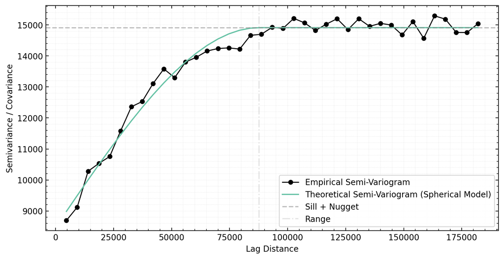

Generally, the variogram is described by 3 paramters. The Sill, the maximum semivarinace the distribution reaches. The Nugget, is the ofset between zero and the lowest semivariance at $h=0$. And the Range, is the maximum $h$ value from where to semivarinace becomes constant and is not increasing anymore.

The formula for the spherical variogram model is given by:

$$\gamma(h) =
\begin{cases}
0 & \text{if } h = 0 \\
C_0 + C_1 \left[ \frac{3h}{2a} - \frac{1}{2} \left( \frac{h}{a} \right)^3 \right] & \text{if } 0 < h \leq a \\
C_0 + C_1 & \text{if } h > a
\end{cases}$$

where: - $h$ is the lag distance, - $C_0$ is the nugget, - $C_1$ is the sill minus the nugget, (*Note:* Sill is $C=C_0+C_1$) - $a$ is the range.

The semivarinace describes the variablitly in our dataset, but for the interpolation tasks we need a measure of the covarinace between our datapoints. The semivariance is directly related to covarinace by the term:

$$Cov(h) = Var(Z) - \gamma(h)$$

Because the sill in our variogramm is the $Var(Z)$ the equation can be easily solved. Or the Covarinace can be calculated directly from the parameters $C_0, C_1, a$.

The Covariance is derived from the Semmivariance:

$$Cov(h) =
\begin{cases}
C_0 + C_1 & \text{if } h = 0 \\
C_1 - C_1 \left[ \frac{3h}{2a} - \frac{1}{2} \left( \frac{h}{a} \right)^3 \right] & \text{if } 0 < h \leq a \\
0 & \text{if } h > a
\end{cases}$$

## Kriging

Krigin as an interpolation technique from the field of geostatistics that uses distance and correlation between the sample points to find the best estimator. Kriging meets the conditions to be the Best Linear Unbiased Estimator (BLUE).

*“Kriging is basically a generalization of minimum mean square error estimation taking into account spatial correlation”* (Sagar, Cheng, and Agterberg 2018)

Kriging is based on the work by the south african miner Danie G. Krige. Several variations of Kriging exists. We discusse the simplest form Simple Kriging, Ordinary Krigin, and Indicator Krigin in this chapter.

In general the estimaton of the attribute value $Z^*(\mathbf{x_0})$ at the interpolation location $\mathbf{x_0}$ is calculated with the weighted mean from the sourrounding points. The weights are based on the variogram modell and thus on the correlation between datapoints.

$$Z^*_{OK}(x_0) = \sum_{i=0}^{n} \lambda_i \cdot z(x_i)$$

This can be demonstrated with the Ordinary Kringing estimator for example. Where $n\leq N$ is a subset of points from the observations closest to the interpolation location. z is the attribut value from the ith observation, and $\lambda_i$ is the weight determined by solving an equation system of the covariance (see next section (Sagar, Cheng, and Agterberg 2018))

### Simple Kriging

The Weigths for the Kriging are Calulated via the Covariance for each interpolation point:

$$\lambda = \mathbf{C^{-1} \cdot c_0}$$

the matrizes looks like that:

$$\lambda =
\begin{bmatrix}
\lambda_1 \\
\lambda_2 \\
\vdots \\
\lambda_2
\end{bmatrix}, \quad
\mathbf{C} =
\begin{bmatrix}
\text{Cov}[x_1, x_1] & \text{Cov}[x_1, x_2] & \cdots & \text{Cov}[x_1, x_n] \\
\text{Cov}[x_2, x_1] & \text{Cov}[x_2, x_2] & \cdots & \text{Cov}[x_2, x_n] \\
\vdots & \vdots & \ddots & \vdots \\
\text{Cov}[x_n, x_1] & \text{Cov}[x_n, x_2] & \cdots & \text{Cov}[x_n, x_n]
\end{bmatrix}, \quad
\mathbf{c}_0 =
\begin{bmatrix}
\text{Cov}(x_1, x_0) \\
\text{Cov}(x_2, x_0) \\
\vdots \\
\text{Cov}(x_n, x_0)
\end{bmatrix}$$

The estimator for $\mathbf{x_0}$ is calculated like:

$$\begin{align*}
Z^*_{SK}(x_0) &= \sum_{i=0}^{n} \lambda_i \cdot (z(x_i) - m) + m \\
\\
\Leftrightarrow \ \
Z^*_{SK}(x_0) &= \lambda^{T} \cdot (\mathbf{Z} - m) + m
\end{align*}$$

The last line is the matrix notation that can be used in python for a faster implementation of the operations. Note that $m=m(x)=constant$ is the mean of $Z$ in the study area

### Ordinary Kriging

Ordinary Kringing fullfills the constraint

$$\sum_{i=0}^{n} \lambda_i \overset{!}{=} 1$$

what leads the the estimation of the espected value (E) in each local neighborhood and ensures the unbiasedness of the estimator.

The Matrix form with the condition:

$$\lambda =
\begin{bmatrix}
\lambda_1 \\
\lambda_2 \\
\vdots \\
\lambda_n \\
\mu_{OK}
\end{bmatrix},
\quad
\mathbf{C} =
\begin{bmatrix}
\text{Cov}[x_1, x_1] & \text{Cov}[x_1, x_2] & \dots & \text{Cov}[x_1, x_n] & 1 \\
\text{Cov}[x_2, x_1] & \text{Cov}[x_2, x_2] & \dots & \text{Cov}[x_2, x_n] & 1 \\
\vdots & \vdots & \ddots & \vdots & \vdots \\
\text{Cov}[x_n, x_1] & \text{Cov}[x_n, x_2] & \dots & \text{Cov}[x_n, x_n] & 1 \\
1 & 1 & \dots & 1 & 0
\end{bmatrix},
\quad
\mathbf{C_0} =
\begin{bmatrix}
\text{Cov}(x_1, x_0) \\
\text{Cov}(x_2, x_0) \\
\vdots \\
\text{Cov}(x_n, x_0) \\
1
\end{bmatrix}$$

From $\lambda = \mathbf{C^{-1} \cdot c_0}$ the weight are calculated.

The estimate at every ${x_0}$ is calculated with:

$$\begin{align*}
Z^*_{OK}(x_0) &= \sum_{i=0}^{n} \lambda_i \cdot z(x_i) \\
\end{align*}$$

or the matrix representation

$$\begin{align*}
\Leftrightarrow \
Z^*_{OK}(x_0) &= \lambda^{T} \cdot \mathbf{Z}
\end{align*}$$
\end{align*} With $\mathbf{Z}$ beeing the list of all observed values and $\lambda^{T}$ the corresponding weights both resulting in one scalar value $Z^*_{OK}(x_0)$.

### Indicator Kriging

Indicator Kriging is a helpful tool to quantify the spatial probability of the occurence of a state of the given datapoints. In our case the probability of the exceedence of a Arsen threshold is calculated. Basis of the indicator kriging is the devision of the data in 2 states; 0 and 1.

With $k_z$ beeing the threshold for the Field $\mathbf{Z}$

Based on the indicator thresholded data, simple or ordinary kriging can be used to estimate the probability of $z\geq k_z$.

When using ordinary kriging, the probability for the exceedence of the threshold is:

$$P^*_{OK}(x_0) = \sum_{i=0}^{n} \lambda_i \cdot z(x_i)$$

Because we used the indicator transformaed data $I(z(x_i),k_z)$ for the kriging function, the result $\mathbf{P^*_{OK}}$ has a value range of $[0,1]$. For every interpolation point $x_0$ the probability $P^*_{OK}(x_0)$ for the threshold exceedence is calculated from the local neigborhood.

## Geostatistical Simulation

# Code

All our functions interface with `geopandas`, especially the `shapely` geometries. Results are wrapped as `xarray.DataArray` object, which are also used for intermediate calculations. `xarray` helps us to keep track of coordinate information and dimension order, which results in more readable code. Further, me make use of CUDA-accelerated functions provided by `cupy` for the computationally intensive parts of the code. Especially this makes the code a little bit more complex, but also much faster. A often found pattern in our code is:

```python
if cp is not None:
    # use cupy
else:
    # use numpy
```

`cp` is a reference to the `cupy` module if that module is present on the system. Else `cp` is `None`, because of the way we import `cupy` (and related libraries):

```python
try:
    import cupy as cp
    ... # import other cupy related libraries
except ImportError:
    cp = None
```

Overview about variable naming (We tried to match literature as close as possible):

- `h`: lag distance
- `z`: dataset values
- `u`: unknown, to be interpolated points
- `c`: c0 (float): The nugget effect.
- `c0`: nugget
- `c1`: sill minus nugget
- `a`: range of the model
- `C0`: Covariances between unknown points and known points
- `Ch`: Covariances between known points

Below are the main functions of our project implemented:

- `fastdist`: A fast version of pairwise distance calculation using `cupy` if available.
- `empirical_semivariogram`: Calculate the empirical semivariogram of a dataset.
- `spherical`: A spherical model, later used for fitting a theoretical semivariogram.
- `spherical_fast`: A reduced spherical model, which does not calculate the sill.
- `cov_from_semivar`: Calculate the covariance from a semivariogram model.
- `ordinary_kriging`: Ordinary Kriging interpolation.
- `ordinary_kriging_simulation`: Sequential (Indicator) Simulation with Ordinary Kriging.

```python
def fastdist(a: gpd.GeoSeries, b: gpd.GeoSeries, to_host: bool = False) -> xr.DataArray:
    """Calculate the pairwise distances between two sets of geometries.

    Utilizes cupy if available for GPU acceleration.

    Args:
        a (gpd.GeoSeries): The first set of geometries.
        b (gpd.GeoSeries): The second set of geometries.
        to_host (bool, optional): Whether to return the result on the host. Defaults to False.

    Returns:
        xr.DataArray: The pairwise distances between the two sets of geometries.

    """
    if cp is not None:
        a_arr = cp.array([a.x, a.y], order="F").T.reshape(-1, 2)
        b_arr = cp.array([b.x, b.y], order="F").T.reshape(-1, 2)
        d = cupyx.scipy.spatial.distance_matrix(a_arr, b_arr)
        if to_host:
            d = d.get()
    else:
        a_arr = np.array([a.x, a.y], order="F").T.reshape(-1, 2)
        b_arr = np.array([b.x, b.y], order="F").T.reshape(-1, 2)
        d = scipy.spatial.distance_matrix(a_arr, b_arr)
    return xr.DataArray(d, dims=("a", "b"), coords={"a": a.index, "b": b.index})
```

```python
def empirical_semivariogram(z: gpd.GeoSeries, geom: gpd.GeoSeries, h: ArrayLike | None = None) -> xr.DataArray:
    """Calculate the empirical semivariogram.

    Args:
        z (gpd.GeoSeries): The data to calculate the semivariogram for.
        geom (gpd.GeoSeries): The geometries of the data. Must be points.
        h (list[float] | None): The bins to calculate the semivariogram for.
            If None, the bins are estimated by linspacing 0 - distances.median() with 40 bins total.
            Defaults to None.

    Returns:
        xr.DataArray: The empirical semivariogram.

    """
    # Calculate the pairwise distances
    d = fastdist(geom, geom, to_host=True).rename({"a": "tail", "b": "head"})
    # Remove upper triangle
    d = d.where(np.triu(np.ones(d.shape), k=1).astype(bool))
    # Remove self-distances
    d = d.where(~np.eye(len(z), dtype=bool))

    # If h is not provided, estimate the lags based on the median distance
    if h is None:
        h = np.linspace(0, d.median(), 40)

    # Calculate the pairwise data differences
    z_head = xr.DataArray(z, coords={"head": z.index}, name="As").expand_dims({"tail": z.index})
    z_tail = xr.DataArray(z, coords={"tail": z.index}, name="As").expand_dims({"head": z.index})
    z_diff = z_head - z_tail

    # Calculate the semivariogram
    gamma = xr.DataArray(0.0, dims=["lag"], coords={"lag": h[1:]})
    for i in range(1, len(h)):
        is_in_lag = (h[i - 1] < d) & (d <= h[i])
        n_h = is_in_lag.sum(dim=["tail", "head"])
        gamma.loc[{"lag": h[i]}] = 1 / (2 * n_h) * (z_diff.where(is_in_lag) ** 2).sum(["tail", "head"])

    # This vectorized approach is taken too much memory, but could potentially be faster:
    # d_lags = xr.DataArray(np.digitize(d, h, right=True), coords={"tail": z.index, "head": z.index})
    # is_in_lag = xr.DataArray(
    #   [d_lags == i for i in range(1, len(h))],
    #   coords={"lag": h[1:], "tail": z.index, "head": z.index}
    # )
    # n_h = is_in_lag.sum(dim=["tail", "head"])
    # gamma = 1 / (2 * n_h) * (z_diff.where(is_in_lag) ** 2).sum(["tail", "head"])

    return gamma
```

```python
def spherical(h: ArrayLike, c0: float, c: float, a: float) -> ArrayLike:
    """Calculate the theoretical semivariogram from a spherical model.

    Args:
        h (ArrayLike): The lags to calculate the semivariogram for.
        c0 (float): The nugget effect.
        c (float): The sill.
        a (float): The range.

    Returns:
        ArrayLike: The spherical semivariogram model.

    """
    semivar = np.zeros_like(h)
    curve_mask = (0 < h) & (h <= a)
    line_mask = h > a
    semivar[curve_mask] = c0 + c * (3 * h[curve_mask] / (2 * a) - 0.5 * (h[curve_mask] / a) ** 3)
    semivar[line_mask] = c0 + c
    return semivar


def spherical_fast(h: ArrayLike, c0: float, c: float, a: float) -> ArrayLike:
    """Calculate the theoretical semivariogram from a spherical model without satisfying constraints.

    Should not be used for fitting!
    Should not be used for h larger than a!

    Args:
        h (ArrayLike): The lags to calculate the semivariogram for.
        c0 (float): The nugget effect.
        c (float): The sill.
        a (float): The range.

    Returns:
        ArrayLike: The spherical semivariogram model.

    """
    return c0 * (h != 0) + c * (3 * h / (2 * a) - 0.5 * (h / a) ** 3)


def cov_from_semivar(semivar: ArrayLike, c0: float, c: float) -> ArrayLike:
    """Calculate the covariance from a semivariogram model.

    Args:
        semivar (ArrayLike): The semivariogram model.
        c0 (float): The nugget effect.
        c (float): The sill.

    Returns:
        ArrayLike: The covariance model.

    """
    return c + c0 - semivar
```

```python
# ruff: noqa: N803, N806
def ordinary_kriging(
    u: gpd.GeoSeries,
    z: gpd.GeoSeries,
    geom: gpd.GeoSeries,
    model_fn: Callable,
    c0: float,
    c: float,
    a: float,
    neighbor_factor: float = 1,
) -> tuple[xr.DataArray, xr.DataArray, xr.DataArray]:
    """Interpolate points u with ordinary kriging based on a fitted semi-variogram model and support points z.

    Args:
        u (gpd.GeoSeries): The points to interpolate ("nodes").
        z (gpd.GeoSeries): The values of the support points.
        geom (gpd.GeoSeries): The geometries of the support points.
        model_fn (Callable): The model function to use for the semi-variogram.
        c0 (float): The nugget effect.
        c (float): The sill.
        a (float): The range.
        neighbor_factor (float, optional): The factor to determine the neighborhood range. Defaults to 0.2.

    Returns:
        tuple[xr.DataArray, xr.DataArray, xr.DataArray]: A tuple containing:
            - The interpolated, kriged values.
            - The kriging variance.
            - The mu value, which is part of the ordinarity constraint.

    """
    # Calculate the covariance matrix C(0) between the unknown points (nodes) and the support points
    d0 = fastdist(geom, u)
    C0 = cov_from_semivar(model_fn(d0, c0, c, a), c0, c)
    # Filter out distances which are larger than the range a, since we don't want to use them
    C0 = C0.where(d0 <= a * neighbor_factor, 0)
    # Rename the dimensions to match our naming scheme for the rest of the function
    C0 = C0.rename({"a": "support", "b": "nodes"})

    # Calculate the pariwise covariance matrix C(h) between the support points
    dh = fastdist(geom, geom)
    Ch = cov_from_semivar(model_fn(dh, c0, c, a), c0, c).rename({"a": "head", "b": "tail"})

    # Apply the constraints that the lambdas must sum up to 1
    C0_constrained = C0.pad({"support": (0, 1)}, constant_values=1)
    Ch_constrained = Ch.pad({"tail": (0, 1), "head": (0, 1)}, constant_values=1)
    Ch_constrained[{"tail": -1, "head": -1}] = 0

    # Calculate the weights on cuda if available, else via numpy
    if cp is not None:
        C0_constrained = C0_constrained.cupy.as_cupy()
        Ch_constrained = Ch_constrained.cupy.as_cupy()
        lam = cp.linalg.solve(
            Ch_constrained.data,
            C0_constrained.data,
        )
    else:
        lam = np.linalg.solve(
            Ch_constrained.data,
            C0_constrained.data,
        )
    lam = xr.DataArray(lam, coords=C0_constrained.coords, name="lambda")
    # Extract the last lambda as the mu, which is part of the ordinarity constraint
    lam, mu = lam[:-1], lam[-1]
    mu = mu.rename("mu")

    # Convert the support values to a DataArray
    z = xr.DataArray(z, coords={"support": z.index})
    if cp is not None:
        z = z.cupy.as_cupy()

    # Calculate the kriged values
    kriged = xr.dot(lam, z, dims="support").rename("kriged")
    # Error calculation
    kriged_var = (c + c0) - xr.dot(lam, C0, dims="support")

    if cp is not None:
        kriged = kriged.cupy.as_numpy()
        kriged_var = kriged_var.cupy.as_numpy()
        mu = mu.cupy.as_numpy()
        cp.get_default_memory_pool().free_all_blocks()

    return kriged, kriged_var, mu
```

```python
# ruff: noqa: N803, N806
def ordinary_kriging_simulation(
    u: gpd.GeoDataFrame,
    z: gpd.GeoSeries,
    geom: gpd.GeoSeries,
    model_fn: Callable,
    c0: float,
    c: float,
    a: float,
    neighbor_factor: float = 0.2,
) -> xr.DataArray:
    """Simulate points u with with ordinary kriging based on a fitted semi-variogram model and support points z.

    Excpects z to be indicators.

    Args:
        u (gpd.GeoSeries): The points to interpolate ("nodes").
        z (gpd.GeoSeries): The values of the support points.
        geom (gpd.GeoSeries): The geometries of the support points.
        model_fn (Callable): The model function to use for the semi-variogram.
        c0 (float): The nugget effect.
        c (float): The sill.
        a (float): The range.
        neighbor_factor (float, optional): The factor to determine the neighborhood range. Defaults to 0.2.

    Returns:
        xr.DataArray: The simulated values

    """
    # Shuffle unknown points to get a random path
    orig_index = u.index
    u = u.sample(frac=1)

    # Precaulate the pairwise distances and their respective covariance matrices by puttin together all geometries
    # In the loop we then can take slices of that large matrix
    # With this we avoid recalculation and concatenation of the covariance matrices in the loop
    all_geoms = pd.concat([geom, u.set_index(u.index + geom.index.max()).geometry])
    d_all = fastdist(all_geoms, all_geoms)
    d_all = d_all.rename({"a": "head", "b": "support"})
    neighbor_range = a * neighbor_factor
    neighbors = (d_all <= neighbor_range).as_numpy()
    C_all = cov_from_semivar(model_fn(d_all, c0, c, a), c0, c)
    C_all = C_all.where(d_all <= a, 0)

    # Turn z into an xarray DataArray with space for the unknown points
    # This array will also contain the simulated values
    z_all = xr.DataArray(0, dims=["support"], coords={"support": all_geoms.index}, name="z")
    z_all.loc[{"support": z.index}] = z

    # Move z to cuda if available
    if cp is not None:
        z_all = z_all.cupy.as_cupy()

    # Create an indicator which points are already in the dataset
    # We calculate this ahead of time to increase speed of the function
    dataset_indicator = xr.DataArray(
        False, dims=["support"], coords={"support": all_geoms.index}, name="dataset_indicator"
    )
    dataset_indicator.loc[{"support": geom.index}] = True

    # Create random generator and random uniform values ahead of time, again to increase speed
    rng = np.random.default_rng()
    r = rng.uniform(size=len(u))

    # i: Iteration counter -> The number of already interpolated points
    # uidx: The index of the unknown point
    # ui: The unknown point
    for i, (uidx, ui) in track(enumerate(u.iterrows()), total=len(u)):
        # Take slices based on current iteration
        # Our C0 and Ch grows with each iteration, because we add more points to our dataset
        # C0 grows linear and Ch grows quadratically
        uidx_adj = uidx + geom.index.max()
        compute_idx = (neighbors.sel(head=uidx_adj) & dataset_indicator).data
        C0 = C_all.sel(head=uidx_adj)[{"support": compute_idx}]
        Ch = C_all[{"support": compute_idx, "head": compute_idx}]

        # Apply the constraints that the lambdas must sum up to 1
        C0_constrained = C0.pad({"support": (0, 1)}, constant_values=1)
        Ch_constrained = Ch.pad({"support": (0, 1), "head": (0, 1)}, constant_values=1)
        Ch_constrained[{"support": -1, "head": -1}] = 0

        # Calculate the weights on cuda if available, else via numpy
        if cp is not None:
            C0_constrained = C0_constrained.cupy.as_cupy()
            Ch_constrained = Ch_constrained.cupy.as_cupy()
            lam = cp.linalg.solve(
                Ch_constrained.data,
                C0_constrained.data,
            )
        else:
            lam = np.linalg.solve(
                Ch_constrained.data,
                C0_constrained.data,
            )
        lam = xr.DataArray(lam, coords=C0_constrained.coords, name="lambda")
        # Extract the last lambda as the mu, which is part of the ordinarity constraint
        lam, _ = lam[:-1], lam[-1]

        # Calculate the kriged values
        kriged_current = z_all[{"support": compute_idx}] @ lam
        # Turn kriged values into a simulated value and add it to the dataset
        z_sim = (kriged_current > r[i]).astype(int)
        z_all.loc[{"support": uidx_adj}] = z_sim
        dataset_indicator.loc[{"support": uidx_adj}] = True

        # Free memory if cuda is used
        if cp is not None:
            del lam, kriged_current, z_sim
            cp.get_default_memory_pool().free_all_blocks()

    # Reindex the adjusted index to the original index to extract the simulated values in original order
    z_all.coords["support"] = z_all.coords["support"] - geom.index.max()
    simulated = z_all.sel(support=orig_index)

    # Move everything back to numpy if cuda was used and free memory
    if cp is not None:
        simulated = simulated.cupy.as_numpy()
        cp.get_default_memory_pool().free_all_blocks()

    return simulated
```

# Results

## Variogram

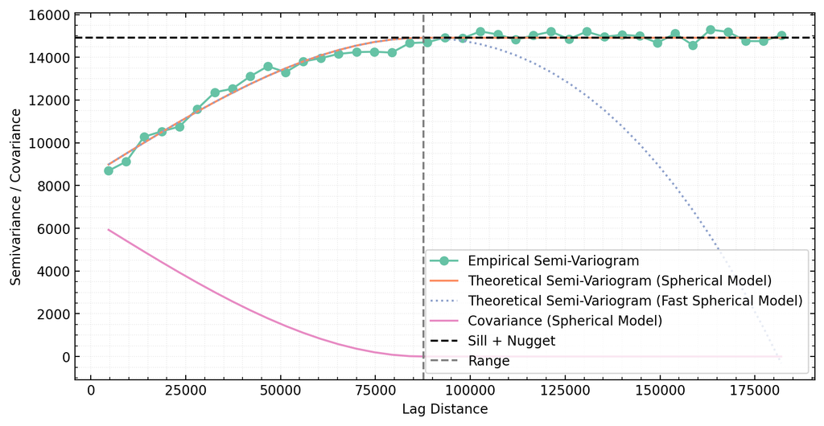

Figure 2: Variogram of arsenic concentration in Bangladesh

```python
fig, ax = plt.subplots(figsize=(10, 5))
gamma.plot(marker="o", ax=ax, label="Empirical Semi-Variogram")
ax.plot(
    gamma.coords["lag"], spherical(gamma.coords["lag"], c0, c, a), label="Theoretical Semi-Variogram (Spherical Model)"
)
ax.plot(
    gamma.coords["lag"],
    spherical_fast(gamma.coords["lag"], c0, c, a),
    linestyle=":",
    label="Theoretical Semi-Variogram (Fast Spherical Model)",
)
ax.plot(
    gamma.coords["lag"],
    cov_from_semivar(spherical(gamma.coords["lag"], c0, c, a), c0, c),
    label="Covariance (Spherical Model)",
)
# Plot horizontal line at sill
ax.axhline(c + c0, color="black", linestyle="--", label="Sill + Nugget")
# Plot vertical line at range
ax.axvline(a, color="grey", linestyle="--", label="Range")
ax.set_xlabel("Lag Distance")
ax.set_ylabel("Semivariance / Covariance")
ax.legend()
# Set legend position to bottom right
ax.legend(loc="lower right")
plt.show()
```

```python
# Indicator encode As values for k = 10 and k = 50
waterquality["As_ind:10"] = (waterquality["As"] >= 10).astype(int)
waterquality["As_ind:50"] = (waterquality["As"] >= 50).astype(int)
```

```python
# Calculate gamma for both thresholds
gamma_10 = empirical_semivariogram(waterquality["As_ind:10"], waterquality.geometry)
gamma_50 = empirical_semivariogram(waterquality["As_ind:50"], waterquality.geometry)

# Fit the spherical model to the empirical semivariogram
(c0_10, c_10, a_10), cov_10 = curve_fit(
    spherical, gamma_10.coords["lag"], gamma_10, p0=[0, gamma_10.mean(), gamma_10.coords["lag"].mean()]
)
(c0_50, c_50, a_50), cov_50 = curve_fit(
    spherical, gamma_50.coords["lag"], gamma_50, p0=[0, gamma_50.mean(), gamma_50.coords["lag"].mean()]
)
print(f"Model parameters for k=10: nugget(c0)={c0_10:.2f}, sill(c)={c_10:.2f}, range(a)={a_10:.2f}")
print(f"Model parameters for k=50: nugget(c0)={c0_50:.2f}, sill(c)={c_50:.2f}, range(a)={a_50:.2f}")
```

```
Model parameters for k=10: nugget(c0)=0.14, sill(c)=0.10, range(a)=103023.87
Model parameters for k=50: nugget(c0)=0.11, sill(c)=0.08, range(a)=130991.17
```

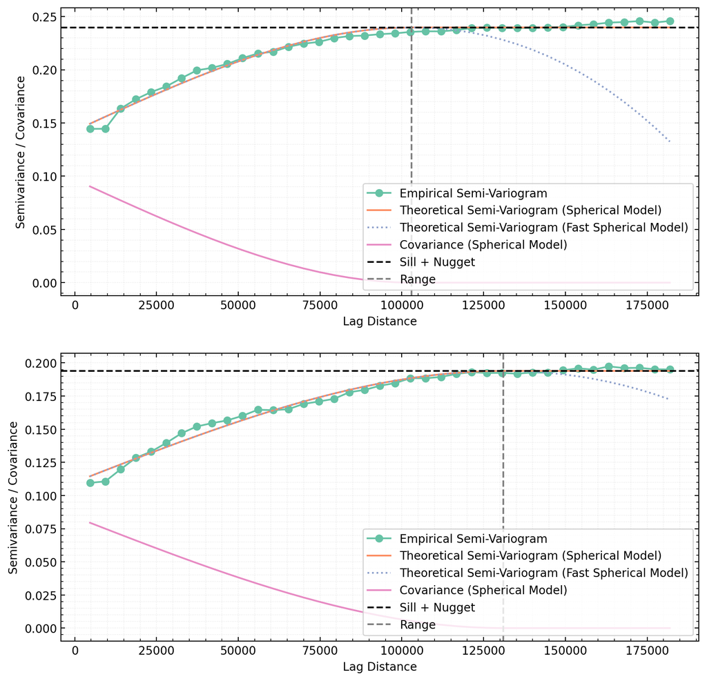

Figure 3: Variogram of indicator coded arsenic concentration in Bangladesh

```python
fig, (ax10, ax50) = plt.subplots(2, 1, figsize=(10, 10))

# Plot the empirical and theoretical semivariograms
gamma_10.plot(marker="o", ax=ax10, label="Empirical Semi-Variogram")
gamma_50.plot(marker="o", ax=ax50, label="Empirical Semi-Variogram")
ax10.plot(
    gamma_10.coords["lag"],
    spherical(gamma_10.coords["lag"], c0_10, c_10, a_10),
    label="Theoretical Semi-Variogram (Spherical Model)",
)
ax50.plot(
    gamma_50.coords["lag"],
    spherical(gamma_50.coords["lag"], c0_50, c_50, a_50),
    label="Theoretical Semi-Variogram (Spherical Model)",
)
ax10.plot(
    gamma_10.coords["lag"],
    spherical_fast(gamma_10.coords["lag"], c0_10, c_10, a_10),
    linestyle=":",
    label="Theoretical Semi-Variogram (Fast Spherical Model)",
)
ax50.plot(
    gamma_50.coords["lag"],
    spherical_fast(gamma_50.coords["lag"], c0_50, c_50, a_50),
    linestyle=":",
    label="Theoretical Semi-Variogram (Fast Spherical Model)",
)
ax10.plot(
    gamma_10.coords["lag"],
    cov_from_semivar(spherical(gamma_10.coords["lag"], c0_10, c_10, a_10), c0_10, c_10),
    label="Covariance (Spherical Model)",
)
ax50.plot(
    gamma_50.coords["lag"],
    cov_from_semivar(spherical(gamma_50.coords["lag"], c0_50, c_50, a_50), c0_50, c_50),
    label="Covariance (Spherical Model)",
)

# Plot horizontal line at sill
ax10.axhline(c_10 + c0_10, color="black", linestyle="--", label="Sill + Nugget")
ax50.axhline(c_50 + c0_50, color="black", linestyle="--", label="Sill + Nugget")
# Plot vertical line at range
ax10.axvline(a_10, color="grey", linestyle="--", label="Range")
ax50.axvline(a_50, color="grey", linestyle="--", label="Range")

# Set labels and legend
ax10.set_xlabel("Lag Distance")
ax10.set_ylabel("Semivariance / Covariance")
ax10.legend(loc="lower right")
ax50.set_xlabel("Lag Distance")
ax50.set_ylabel("Semivariance / Covariance")
ax50.legend(loc="lower right")
plt.show()
```

## Kriging

For kriging, a regular grid with a resolution of 2000 meters was created to cover the area of interest. The grid points were generated using a mesh grid that spanned the bounding box of the survey area. After generation, the grid was filtered to retain only points within the defined survey area, ensuring that interpolation was performed only in relevant regions.

```python
# Create a grid, spanning the area of interest
res = 2000  # m
x = np.arange(surveyarea.bounds.minx.item(), surveyarea.bounds.maxx.item(), res)
y = np.arange(surveyarea.bounds.miny.item(), surveyarea.bounds.maxy.item(), res)
X, Y = np.meshgrid(x, y)
grid_gdf = gpd.GeoDataFrame(geometry=gpd.points_from_xy(X.ravel(), Y.ravel(), crs=surveyarea.crs))
# Filter out points that are not within the survey area
grid_gdf = grid_gdf[grid_gdf.within(surveyarea.loc[0, "geometry"])]
```

```python
# Calculate the kriged values for the grid
grid_gdf["kriged"], grid_gdf["kriged_var"], grid_gdf["mu"] = ordinary_kriging(
    grid_gdf.geometry, waterquality["As"], waterquality.geometry, spherical_fast, c0, c, a
)
```

### Ordinary kriging

```python
vmax = np.percentile(waterquality["As"], 95)
kriged_grid = _sparse_to_xarray_direct(grid_gdf, "kriged")
kriged_var_grid = _sparse_to_xarray_direct(grid_gdf, "kriged_var")

m_kriged = folium.Map(tiles="CartoDB positron")
waterquality.explore(m=m_kriged, column="As", cmap="PiYG_r", vmax=vmax, name="As (µg/L)")
kriged_grid.odc.explore(m_kriged, cmap="coolwarm", name="Kriged As (µg/L)")
kriged_var_grid.odc.explore(m_kriged, cmap="GnBu", name="Kriged Variance")
surveyarea.boundary.explore(m=m_kriged, style_kwds={"fill": False, "color": "black"}, name="Survey Area")
folium.LayerControl().add_to(m_kriged)
folium.FitOverlays().add_to(m_kriged)
m_kriged
```

Make this Notebook Trusted to load map: File -> Trust Notebook

[interactive chart not shown]

Figure 4: Kriged arsenic concentration in Bangladesh

### Indicator kriging

```python
grid_gdf["kriged_10"], grid_gdf["kriged_var_10"], grid_gdf["mu_10"] = ordinary_kriging(
    grid_gdf.geometry, waterquality["As_ind:10"], waterquality.geometry, spherical_fast, c0_10, c_10, a_10
)
grid_gdf["kriged_50"], grid_gdf["kriged_var_50"], grid_gdf["mu_50"] = ordinary_kriging(
    grid_gdf.geometry, waterquality["As_ind:50"], waterquality.geometry, spherical_fast, c0_50, c_50, a_50
)

vmax = np.percentile(waterquality["As"], 95)
kriged_grid = _sparse_to_xarray_direct(grid_gdf, "kriged_10")
kriged_var_grid = _sparse_to_xarray_direct(grid_gdf, "kriged_var_10")

m_kriged = folium.Map(tiles="CartoDB positron")
waterquality.explore(m=m_kriged, column="As", cmap="PiYG_r", vmax=vmax, name="As (µg/L)")
kriged_grid.odc.explore(m_kriged, cmap="coolwarm", name="Indicator Kriged As < 10 ug/L")
kriged_var_grid.odc.explore(m_kriged, cmap="GnBu", name="Indicator Kriged Variance")
surveyarea.boundary.explore(m=m_kriged, style_kwds={"fill": False, "color": "black"}, name="Survey Area")
folium.LayerControl().add_to(m_kriged)
folium.FitOverlays().add_to(m_kriged)
m_kriged
```

Make this Notebook Trusted to load map: File -> Trust Notebook

[interactive chart not shown]

```python
vmax = np.percentile(waterquality["As"], 95)
kriged_grid = _sparse_to_xarray_direct(grid_gdf, "kriged_50")
kriged_var_grid = _sparse_to_xarray_direct(grid_gdf, "kriged_var_50")

m_kriged = folium.Map(tiles="CartoDB positron")
waterquality.explore(m=m_kriged, column="As", cmap="PiYG_r", vmax=vmax, name="As (µg/L)")
kriged_grid.odc.explore(m_kriged, cmap="coolwarm", name="Indicator Kriged As < 50 ug/L")
kriged_var_grid.odc.explore(m_kriged, cmap="GnBu", name="Indicator Kriged Variance")
surveyarea.boundary.explore(m=m_kriged, style_kwds={"fill": False, "color": "black"}, name="Survey Area")
folium.LayerControl().add_to(m_kriged)
folium.FitOverlays().add_to(m_kriged)
m_kriged
```

Make this Notebook Trusted to load map: File -> Trust Notebook

[interactive chart not shown]